```r
#setRepositories(ind=1:2)
#install.packages("WGCNA")
#source("http://bioconductor.org/biocLite.R")
#biocLite("AnnotationDbi", type="source")
#biocLite("GO.db")

library(readxl)
library(dplyr)
library(reshape2)
library(ggplot2)
library(knitr)
library(MASS)
library(BSDA)
library(WGCNA)
library(gridExtra)
library(randomForest)
library(fuzzyforest)
```

## Problem Statement

HIV is a virus that afflicts millions of people around the world. There are several goals in this analysis: (1) assess differences between HIV and non-HIV patients (2) understand the relationship between raw and genetic age based on all patients and based on stratification by HIV (3) find predictors for aging (3) assess the effect of medication over time on HIV patients via genetic biomarkers. The dataset contains information from 30 patients collected over the span of 3 visits.

## Methods

A variety of methods were used. In part 1, we use Wilcoxon Rank Sum Test, Wilcoxon Signed Rank Test, and Fisher Sign Test. In part 2, we use fuzzy forest which is a collective of WGCNA and Random Forest.

## Part 1. Data Analysis with WRST, WSRT, and Fisher Sign Test

```r
hiv <- read_excel('C:/Users/mondals/Desktop/final_project.xlsx')
```

```r
hiv_contents <- apply(hiv, 2,unique)

hiv_tables <- apply(hiv, 2, function(x) addmargins(table(x))) #no missing values
```

There are no missing values. The data is not equally spaced since the visits are occurring at different times (noted from the fact that the visit dates differed from patient to patient).

```r
#how many patients total
num_patients<- length(table(hiv$Patient_ID))

#find proportions of hiv infected vs noninfected
hiv_props <- hiv %>%
  filter(visit == 1) %>% group_by(HIV) %>% summarize(count = n())
hiv_props
```

```
## # A tibble: 2 x 2
##     HIV count
##   <dbl> <int>
## 1     0    15
## 2     1    15
```

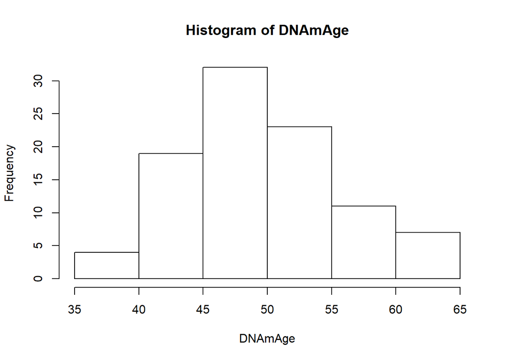

```r
#look at DNAmAge
hist(hiv$DNAmAge, main = 'Histogram of DNAmAge', xlab = 'DNAmAge')
```

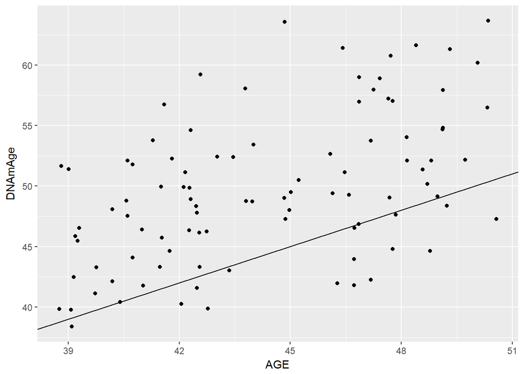

```r
#how does DNAmage compare to AGE?
ggplot(data = hiv) +
  geom_point(mapping = aes(x = AGE, y = DNAmAge)) +
  geom_abline(slope = 1)
```

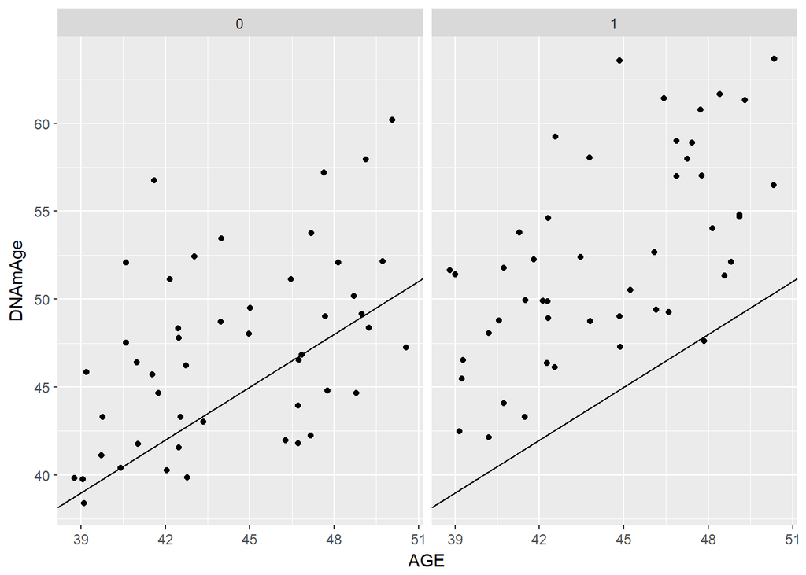

```r
ggplot(data= hiv) +
  geom_point(mapping = aes(x = AGE, y = DNAmAge)) +
  geom_abline(slope = 1) +
  facet_grid(~HIV)
```

As a primary exploration, I look at DNA methylation age(?) as a linear function of AGE. In particular, I wanted to look to see if patient’s actual age correspond to their DNAmage. If they did, all points would fall along the y = x line. What we see here is that for most patients, their DNAmAge is greater than than their actual age. We could have probably observed that by looking the AgeAccelerationDiff variable though :).

When we look at DNAmAGE as as outcome variable by HIV infected and non-infected groups, we see that almost everyone has higher DNAmAGEs compared to their actual age.

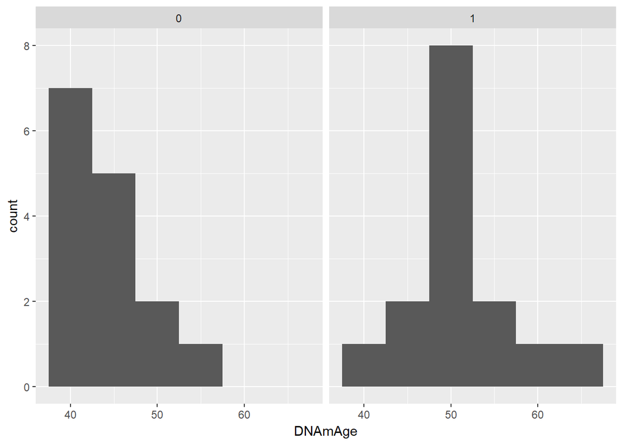

```r
#Is there a difference between DNAmAGE between HIV and non HIV patients at baseline?

hiv_baseline <- hiv %>%
  filter(visit == 1)

ggplot(data = hiv_baseline) + geom_histogram(mapping = aes(x = DNAmAge), binwidth = 5) +
  facet_grid(~HIV)
```

At baseline, when we compare DNAmAge, we see that the age distribution is also further to the right for the HIV patients, but that that the distribution is right skewed for non-HIV patients. The age distribution is more normally distributed for HIV infected patients. The mean DNAmAGE for HIV non infected patients seems lower than infected patients.

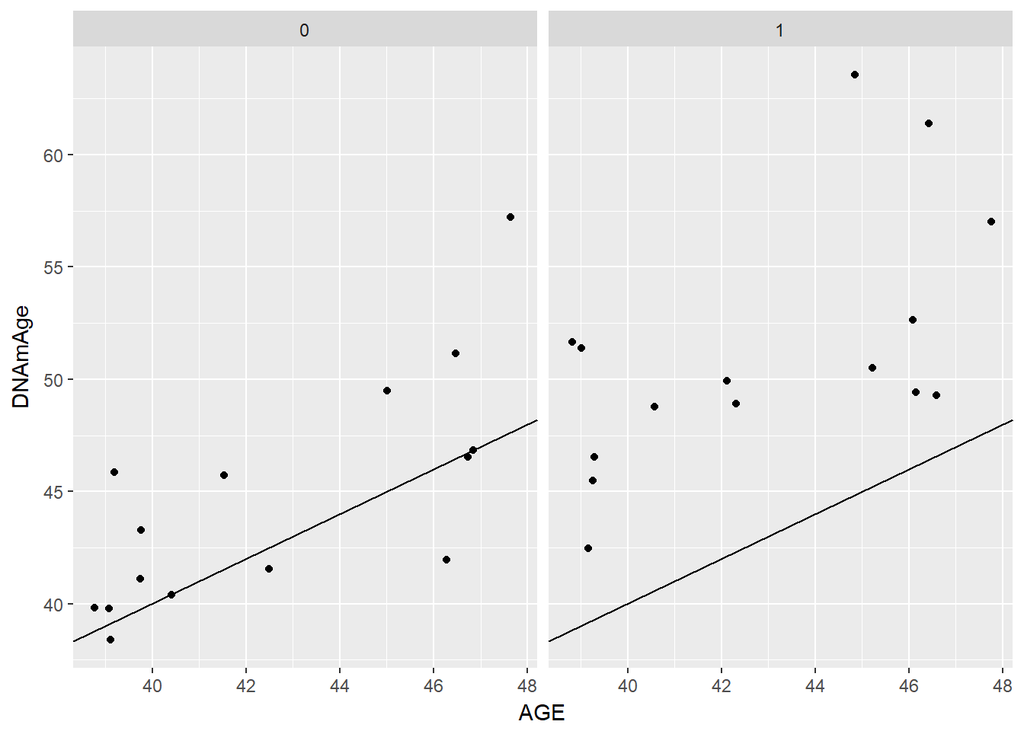

```r
ggplot (data = hiv_baseline) +
  geom_point(mapping = aes(x = AGE, y = DNAmAge)) +
  geom_abline(slope = 1) +
  facet_grid(~HIV)
```

Even at baseline, we see that for HIV infected patients, DNAmAge is greater than actual AGe.

```r
#Is the difference in median DNAmAge for HIV and non-HIV patients significant?

noHIV<- hiv_baseline$DNAmAge[hiv_baseline$HIV == 0]
HIV<- hiv_baseline$DNAmAge[hiv_baseline$HIV == 1]

#use wilcoxon rank sum test
wilcox.test(HIV, noHIV, alternative = 'two.sided')
```

```
##
##  Wilcoxon rank sum test
##
## data:  HIV and noHIV
## W = 186, p-value = 0.001665
## alternative hypothesis: true location shift is not equal to 0
```

There is evidence to suggest that that the median DNAmAge for HIV patients is greater than the median DNAmgAGE for nonHIV patients at baseline (W = 186, p-val = .002). Basically, there is evidence to suggest that HIV ages you.

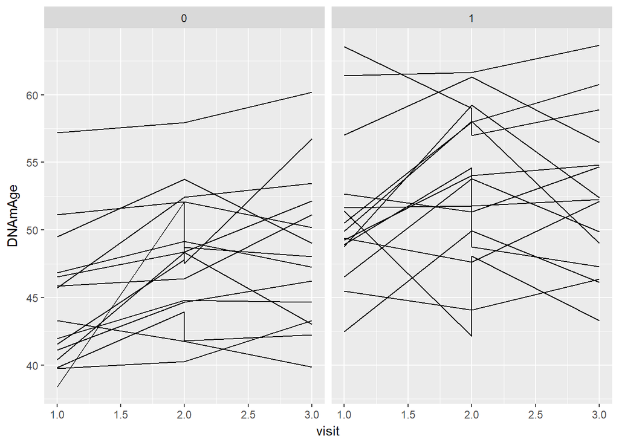

```r
#DNAmage across all timepoints
ggplot(data = hiv) + geom_line(mapping = aes(x = visit , y = DNAmAge,
                                             group = Patient_ID)) +
                    facet_grid(~HIV)
```

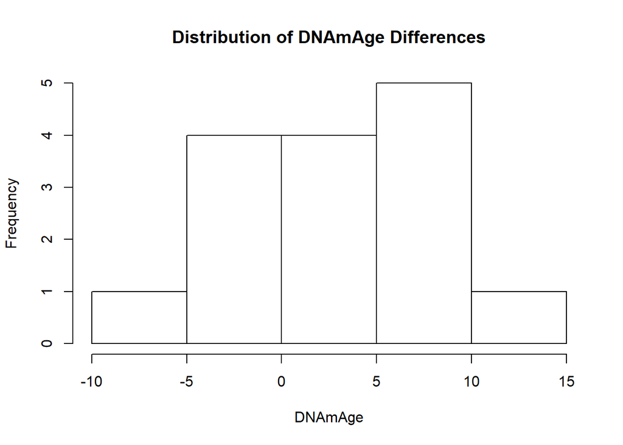

```r
#Effect of medication between visit 1 and 2 for HIV patients
hiv1 <- hiv %>% filter(HIV == 1) %>%
  group_by(Patient_ID) %>%
  summarize(diff1 = DNAmAge[2]-DNAmAge[1])

hist(hiv1$diff1, main = 'Distribution of DNAmAge Differences',
     xlab = 'DNAmAge')
```

```r
hiv1_vis12 <- hiv %>%
  filter(HIV == 1) %>% group_by(Patient_ID) %>%
  summarize(fir_vis = DNAmAge[1],
            second_vis = DNAmAge[2])


wilcox.test(x = hiv1_vis12$fir_vis, y = hiv1_vis12$second_vis, paired = TRUE)
```

```
##
##  Wilcoxon signed rank test
##
## data:  hiv1_vis12$fir_vis and hiv1_vis12$second_vis
## V = 33, p-value = 0.1354
## alternative hypothesis: true location shift is not equal to 0
```

Upon inspection, we see that the DNAmAge is higher at second visit. However, statistically speaking, there is no evidence to suggest that the median DNAmAge between the first and second visits are different at the alpha level .05 for HIV patients (V = 33, p-val = .1354). This suggests that between visits 1 and 2 there was no medication effect. This would make sense because patients were only given HIV medication at the second visit.

Now we would like to see if there was a medication effect across time. We see that there is no medication effect from Visit 1 to Visit 2, perhaps there could be a medication effect from Visit 2 to Visit 3.

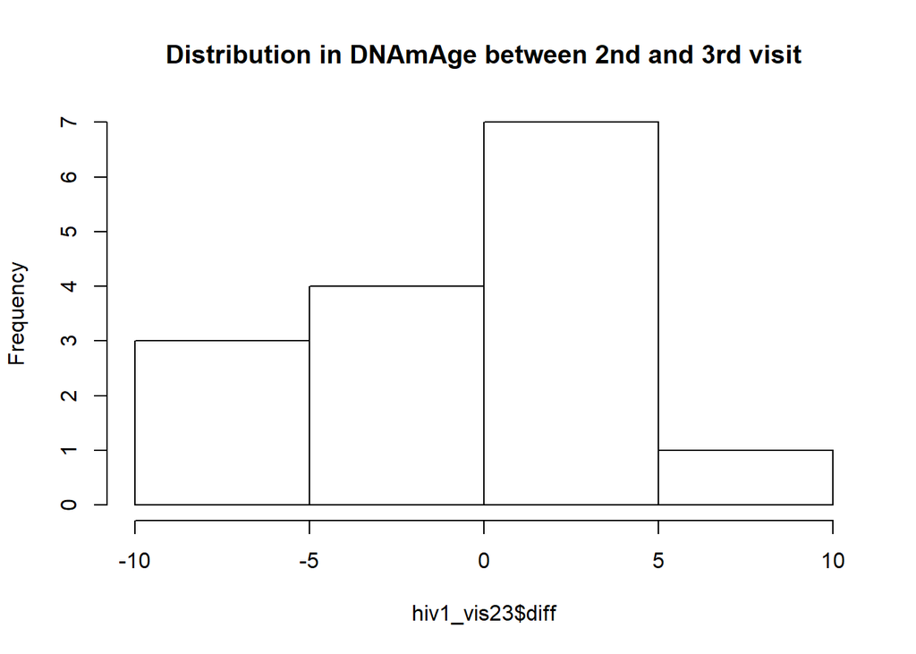

```r
hiv1_vis23 <- hiv %>%
  filter(HIV == 1) %>%
  group_by(Patient_ID) %>%
  summarize(second_vis = DNAmAge[2],
            third_vis = DNAmAge[3]) %>%
  mutate(diff = third_vis-second_vis)

hist(hiv1_vis23$diff, main = 'Distribution in DNAmAge between 2nd and 3rd visit')
```

```r
SIGN.test(hiv1_vis23$diff)
```

```
##
##  One-sample Sign-Test
##
## data:  hiv1_vis23$diff
## s = 8, p-value = 1
## alternative hypothesis: true median is not equal to 0
## 95 percent confidence interval:
##  -4.657058  2.698170
## sample estimates:
## median of x
##   0.4756331
##
## Achieved and Interpolated Confidence Intervals:
##
##                   Conf.Level  L.E.pt U.E.pt
## Lower Achieved CI     0.8815 -3.9095 2.2649
## Interpolated CI       0.9500 -4.6571 2.6982
## Upper Achieved CI     0.9648 -4.8191 2.7921
```

Similarly here, the distribution is more left skewed. We apply Fisher Sign Test, even though it has less power.

There are many biomarkers that are associated with HIV. Here, we will work with 5 specifically: T4_DRn38ponROp4p, T4_DRp38ponROp4p, T4_DRn38pon4p, T4_DRn38ponROp8p, T4_DRn38pon8p.

We would like to visualize differences in levels of expression for these 5 biomarkers between HIV and non-HIV patients at baseline and if these differences are statistically significant.

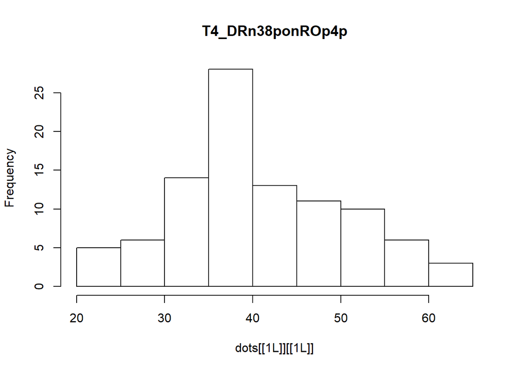

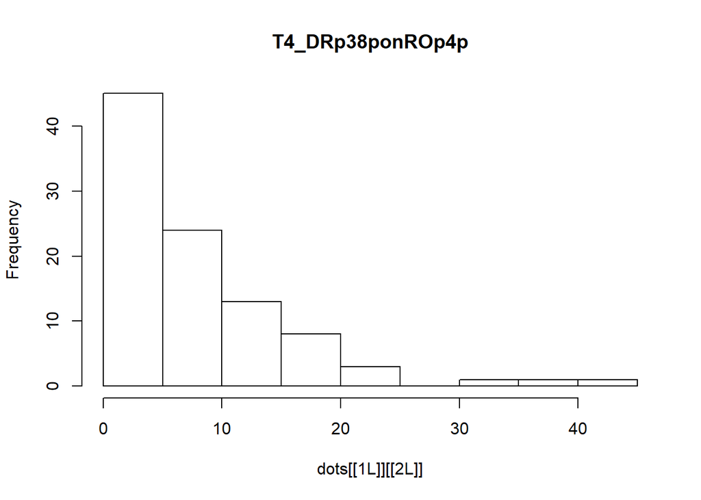

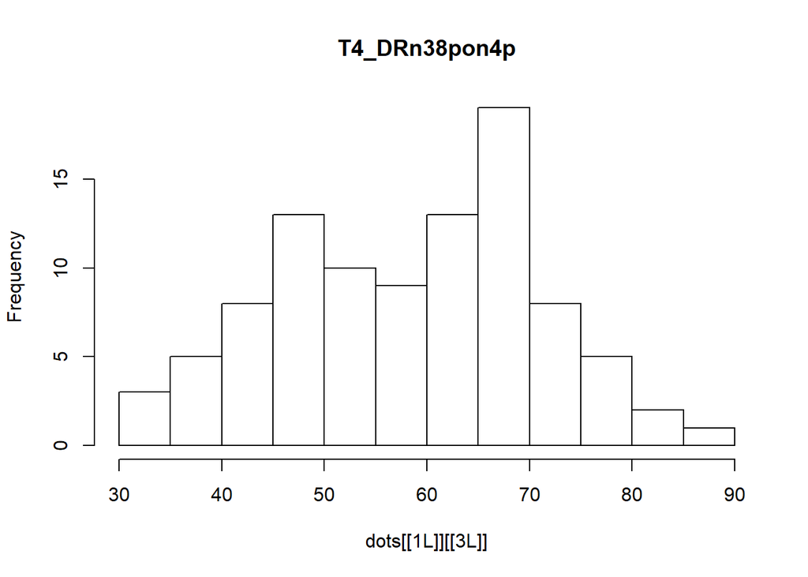

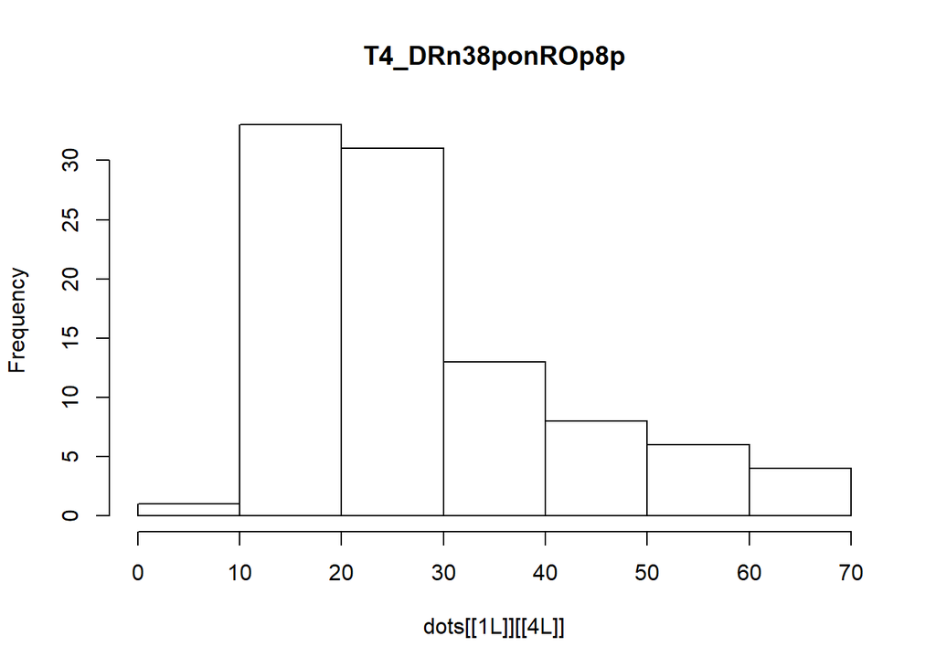

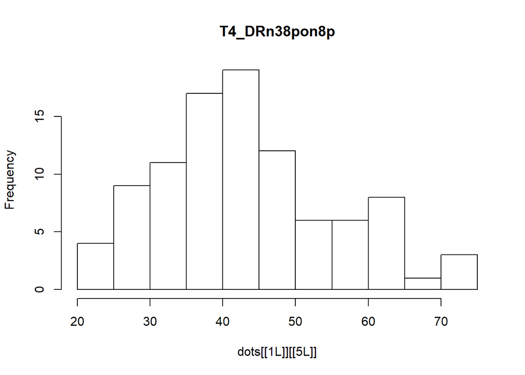

```r
marker_hist <- hiv[,c('HIV',
                      'T4_DRn38ponROp4p',
                      'T4_DRp38ponROp4p',
                      'T4_DRn38pon4p',
                      'T4_DRn38ponROp8p',
                      'T4_DRn38pon8p')]

titles <- names(marker_hist)[2:6]
invisible(mapply(hist, marker_hist[2:6], main = titles))
```

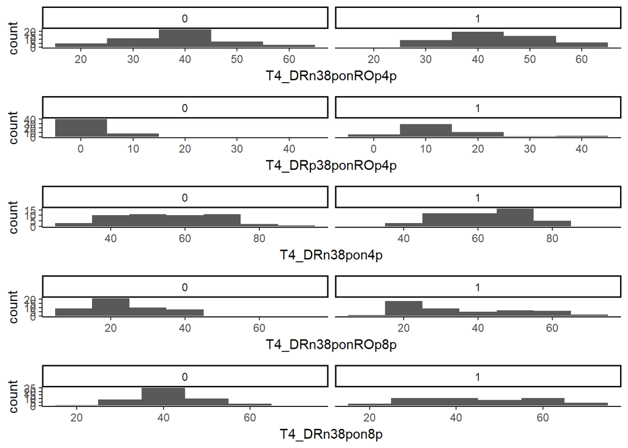

```r
mark1<- ggplot (data = marker_hist) +
  geom_histogram(mapping = aes(x = T4_DRn38ponROp4p), binwidth = 10) +
  facet_grid(~HIV) + theme_classic()

mark2 <- ggplot(data = marker_hist) +
  geom_histogram(mapping = aes(x = T4_DRp38ponROp4p), binwidth = 10) +
  facet_grid(~HIV) +
  theme_classic()

mark3 <- ggplot(data = marker_hist) +
  geom_histogram(mapping = aes(x = T4_DRn38pon4p), binwidth = 10) +
  facet_grid(~HIV) +
  theme_classic()

mark4 <- ggplot(data = marker_hist) +
  geom_histogram(mapping = aes(x = T4_DRn38ponROp8p), binwidth = 10) +
  facet_grid(~HIV) +
  theme_classic()

mark5 <- ggplot(data = marker_hist) +
  geom_histogram(mapping = aes(x = T4_DRn38pon8p), binwidth = 10) +
  facet_grid(~HIV) +
  theme_classic()

grid.arrange(mark1, mark2, mark3, mark4, mark5,
             nrow = 5)
```

```r
#Are there differences without drugs?
wilcox.test(x = hiv$T4_DRn38ponROp4p[hiv$HIV == 0 & hiv$visit == 1], y = hiv$T4_DRn38ponROp4p[hiv$HIV == 1 & hiv$visit == 1])
```

```
##
##  Wilcoxon rank sum test with continuity correction
##
## data:  hiv$T4_DRn38ponROp4p[hiv$HIV == 0 & hiv$visit == 1] and hiv$T4_DRn38ponROp4p[hiv$HIV == 1 & hiv$visit == 1]
## W = 60.5, p-value = 0.03263
## alternative hypothesis: true location shift is not equal to 0
```

```r
wilcox.test(x = hiv$T4_DRp38ponROp4p[hiv$HIV == 0 &hiv$visit == 1], y = hiv$T4_DRp38ponROp4p[hiv$HIV == 1 & hiv$visit == 1])
```

```
##
##  Wilcoxon rank sum test with continuity correction
##
## data:  hiv$T4_DRp38ponROp4p[hiv$HIV == 0 & hiv$visit == 1] and hiv$T4_DRp38ponROp4p[hiv$HIV == 1 & hiv$visit == 1]
## W = 6, p-value = 1.097e-05
## alternative hypothesis: true location shift is not equal to 0
```

```r
wilcox.test(x = hiv$T4_DRn38pon4p[hiv$HIV == 0 & hiv$visit == 1], y = hiv$T4_DRn38pon4p[hiv$HIV == 1 & hiv$visit == 1])
```

```
##
##  Wilcoxon rank sum test with continuity correction
##
## data:  hiv$T4_DRn38pon4p[hiv$HIV == 0 & hiv$visit == 1] and hiv$T4_DRn38pon4p[hiv$HIV == 1 & hiv$visit == 1]
## W = 95, p-value = 0.4806
## alternative hypothesis: true location shift is not equal to 0
```

```r
wilcox.test(x = hiv$T4_DRn38ponROp8p[hiv$HIV == 0 & hiv$visit == 1], y = hiv$T4_DRn38ponROp8p[hiv$HIV == 1 & hiv$visit == 1])
```

```
##
##  Wilcoxon rank sum test with continuity correction
##
## data:  hiv$T4_DRn38ponROp8p[hiv$HIV == 0 & hiv$visit == 1] and hiv$T4_DRn38ponROp8p[hiv$HIV == 1 & hiv$visit == 1]
## W = 83.5, p-value = 0.2371
## alternative hypothesis: true location shift is not equal to 0
```

```r
wilcox.test(x = hiv$T4_DRn38pon8p[hiv$HIV == 0 & hiv$visit == 1], y = hiv$T4_DRn38pon8p[hiv$HIV == 1 & hiv$visit == 1])
```

```
##
##  Wilcoxon rank sum test with continuity correction
##
## data:  hiv$T4_DRn38pon8p[hiv$HIV == 0 & hiv$visit == 1] and hiv$T4_DRn38pon8p[hiv$HIV == 1 & hiv$visit == 1]
## W = 103.5, p-value = 0.7244
## alternative hypothesis: true location shift is not equal to 0
```

Upon noticing that levels of gene expression differ for all the biomarkers and that gene expression also differs between HIV positive and HIV negative groups, we test to see whether differences in gene expression between HIV positive and HIV negative groups are statistically significant. We will use Wilcoxon Rank Sum Test to do so. Most distributions were symmetric enough so that this assumption is not violated with the exception of ‘T4_DRp38ponROp4p’ and ‘T4_DRn38pon4p’. For the latter biomarkers mentioned, even the assumption is violated, we will still apply WRST to test for differences in levels of expression.

When we apply the Wilcoxon Rank Sum Test, we see that ‘T4_DRn38ponROp4p’ and ‘T4_DRp38ponROp4p’, there are statistically significant differences in median levels of expression when we compare HIV positive patients to non-HIV positive patients at baseline. It should also be noted that R does not add a tie correction to the Wilcoxon Rank Sum exact calculation; rather R uses large sample approximation when there is ties. This might skew the p-values reported above since n is only 15.

### Conclusions

- We observe that for most patients DNAmAge is greater than actual age. For HIV patients, all DNAmAges were greater than actual ages. The median DNAmage for HIV patients was significantly greater than median DNmage for HIV negative patients.
- Medication for HIV patients did not seem to be effective as there was no medication effect between timepoint 1 and 2 or from timepoints 2 to 3. More research should be conducted to explore the medication effect.
- We see that biomarker expression for the 5 biomarkers selected between the HIV sub-groups for all time points. In particular, we notice significant differences in expression for biomarkers ‘T4_DRn38ponROp4p’ and ‘T4_DRp38ponROp4p’ when no medication was given. Next steps of the analysis would be to look if there are changes in expression across time amongst HIV patients and if there are changes in expression across timepoints when we compare HIV to non-HIV patients.Furthermore, the interaction between aging, gene expression, and HIV should also be explored to build up on the latter analysis. What we have provided here is a very broad overview.

## Part 2. Fuzzy Forest

We have seen above that most patients are experiencing age acceleration at the genetic level and HIV patients tend to age faster than the non-HIV patients.

Hence, the goal of this analysis was to understand which predictors are most related to AgeAccelDiff (the difference between DNAmAge and actual age) in an attempt to understand which factors cause patients to age fastest. We will utilize both HIV negative and HIV positive patients in the same analysis, even though there are inherent differences between the two groups.

```r
set.seed(1)
ind_vars <- hiv[,!names(hiv) %in% c('Patient_ID', 'AGE', 'DNAmAge',
                                    'BirthYear', 'VisitYear', 'AgeAccelerationDiff',
                                    'AgeAccel2', 'AgeAccelerationResidual')]

resp_vars <- data.frame(hiv[,'AgeAccelerationDiff'])
resp_vars <- resp_vars[,1]
```

```r
net <- blockwiseModules(ind_vars, power = 6, minModuleSize = 1)
```

```r
module_membership <- net$colors
```

```r
#my own parameters
mtry_factor <- 1
min_ntree <- 500
drop_fraction <- .7
ntree_factor <- 1
nodesize <- 1

screen_params <- screen_control(
  drop_fraction = drop_fraction,
  keep_fraction = .2,
  min_ntree = min_ntree,
  ntree_factor = ntree_factor,
  mtry_factor = mtry_factor
)

select_params <- select_control(
  drop_fraction = drop_fraction,
  number_selected = 5,
  min_ntree = min_ntree,
  ntree_factor = ntree_factor,
  mtry_factor = mtry_factor
)
```

```r
ff_fit <- ff(X = ind_vars, y = resp_vars, module_membership = module_membership,
            screen_params = screen_params, select_params=select_params)
```

```r
#default settings

ff_fit2 <- ff(X = ind_vars, y = resp_vars, module_membership = module_membership,
              screen_params = screen_control(keep_fraction = .5),
              select_params = select_control(number_selected = 5))
```

```r
kable(ff_fit$module_membership[order(ff_fit$module_membership$module),])
```

|  | feature_name | module |
| --- | --- | --- |
| 19 | T4_DRp38ponROp8p | black |
| 23 | T4_DRp38pon8p | black |
| 10 | T4_DRn38ponROp4p | blue |
| 12 | T4_DRn38nonROp4p | blue |
| 14 | T4_DRn38pon4p | blue |
| 16 | T4_DRn38non4p | blue |
| 1 | visit | brown |
| 2 | Visit1 | brown |
| 4 | Visit3 | brown |
| 21 | T4_DRp38nonROp8p | green |
| 25 | T4_DRp38non8p | green |
| 3 | Visit2 | grey |
| 6 | meanMethBySample | grey |
| 7 | Female | grey |
| 11 | T4_DRp38ponROp4p | pink |
| 15 | T4_DRp38pon4p | pink |
| 18 | T4_DRn38ponROp8p | red |
| 22 | T4_DRn38pon8p | red |
| 5 | HIV | turquoise |
| 8 | AbsCD8 | turquoise |
| 9 | AbsCD4 | turquoise |
| 20 | T4_DRn38nonROp8p | turquoise |
| 24 | T4_DRn38non8p | turquoise |
| 13 | T4_DRp38nonROp4p | yellow |
| 17 | T4_DRp38non4p | yellow |

Before we observe the fuzzy forest results, we attempt to visualize all the modules. For the most part, the modules seem well chosen. For example, all visits were placed in the ‘brown’ module and ‘hiv’ and ‘abscd8/abscd4’ were placed in the turquoise model. Although it is a little strange that visit 2 was placed in the ‘grey’ module. We see that all the biomarkers were placed in distinct clusters as well with the exception of ‘T4_DRn38nonROp8p’ and ‘T4_DRn38non8p’ which were placed in the turquoise module with HIV related features.

```r
final_rf <- ff_fit$final_rf
final_rf2 <- ff_fit2$final_rf

final_rf
```

```
##
## Call:
##  randomForest(x = final_X, y = y, xtest = test_features, ytest = test_y,      ntree = final_ntree, mtry = final_mtry, nodesize = nodesize,      importance = TRUE)
##                Type of random forest: regression
##                      Number of trees: 5000
## No. of variables tried at each split: 2
##
##           Mean of squared residuals: 17.45398
##                     % Var explained: 37.05
```

```r
final_rf2
```

```
##
## Call:
##  randomForest(x = final_X, y = y, xtest = test_features, ytest = test_y,      ntree = final_ntree, mtry = final_mtry, nodesize = nodesize,      importance = TRUE)
##                Type of random forest: regression
##                      Number of trees: 5000
## No. of variables tried at each split: 2
##
##           Mean of squared residuals: 17.23853
##                     % Var explained: 37.83
```

```r
rankings <- ff_fit$feature_list
rankings
```

```
##       feature_name variable_importance module_membership
## 2    T4_DRp38pon4p           10.546335              pink
## 1           AbsCD8            5.213871         turquoise
## 4 T4_DRn38ponROp8p            3.046228               red
## 5    T4_DRp38pon8p            2.997758             black
## 3    T4_DRp38non4p            2.415913            yellow
```

```r
rankings2 <- ff_fit2$feature_list
rankings2
```

```
##       feature_name variable_importance module_membership
## 2    T4_DRp38pon4p            9.455118              pink
## 3 T4_DRn38nonROp8p            5.682114         turquoise
## 1           AbsCD8            4.841551         turquoise
## 5    T4_DRn38non8p            4.335525         turquoise
## 4    T4_DRp38pon8p            3.255172             black
```

In the untuned model, we observe that the most important feature is still ‘T4_DRp38pon4p’.

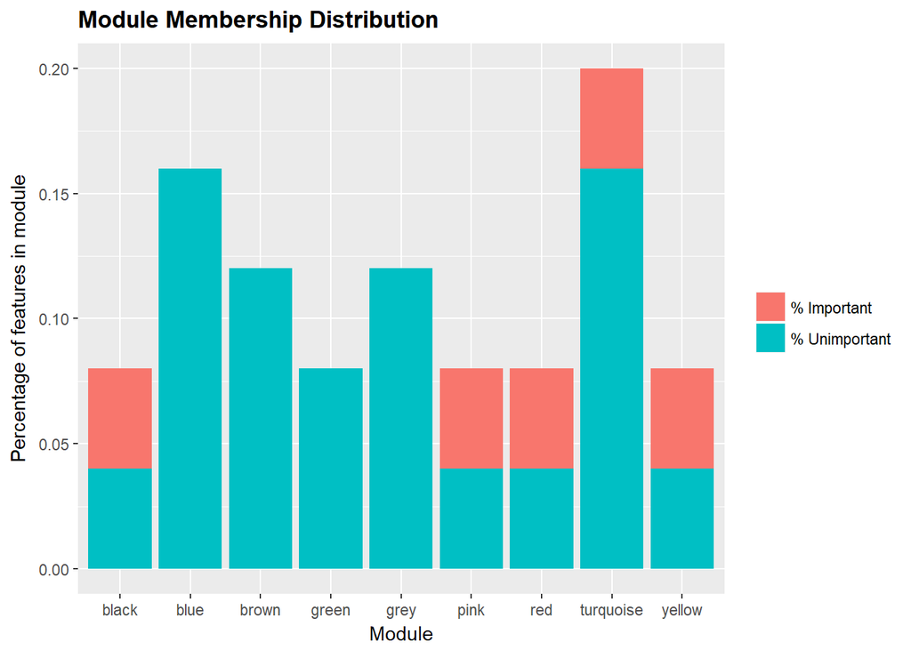

```r
modplot(ff_fit)
```

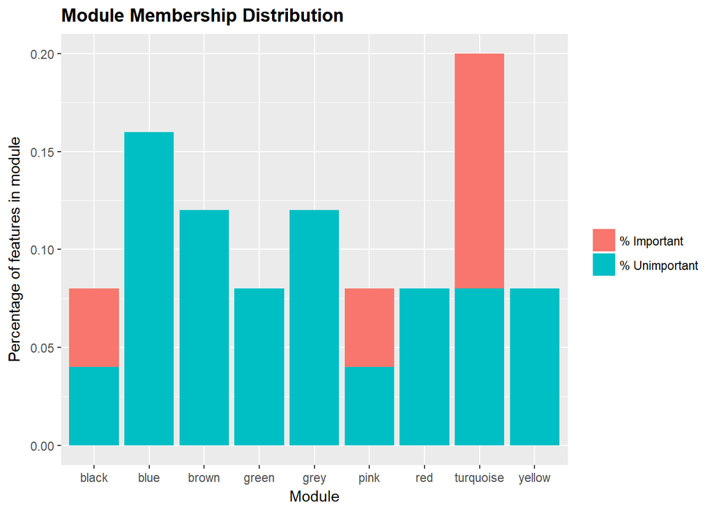

```r
modplot(ff_fit2)
```

This suggests that there might be a relationship between HIV and aging as the turquoise module seems to contain predictors more inherently related to HIV.

We are not sure about the relationships for the other modules. We will need to consult with a immunologist about potential plausible relationships.

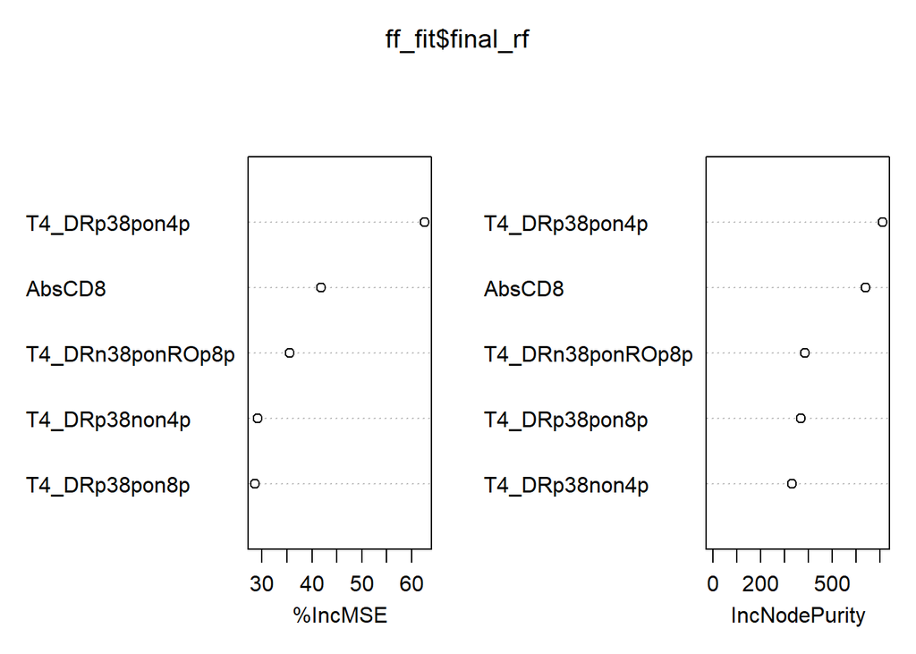

```r
varImpPlot(ff_fit$final_rf)
```

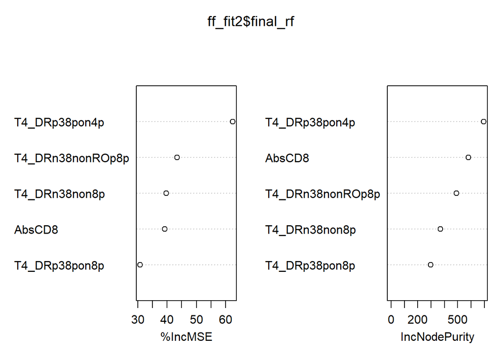

```r
varImpPlot(ff_fit2$final_rf)
```

This is another visualization of variable important scores for both models.

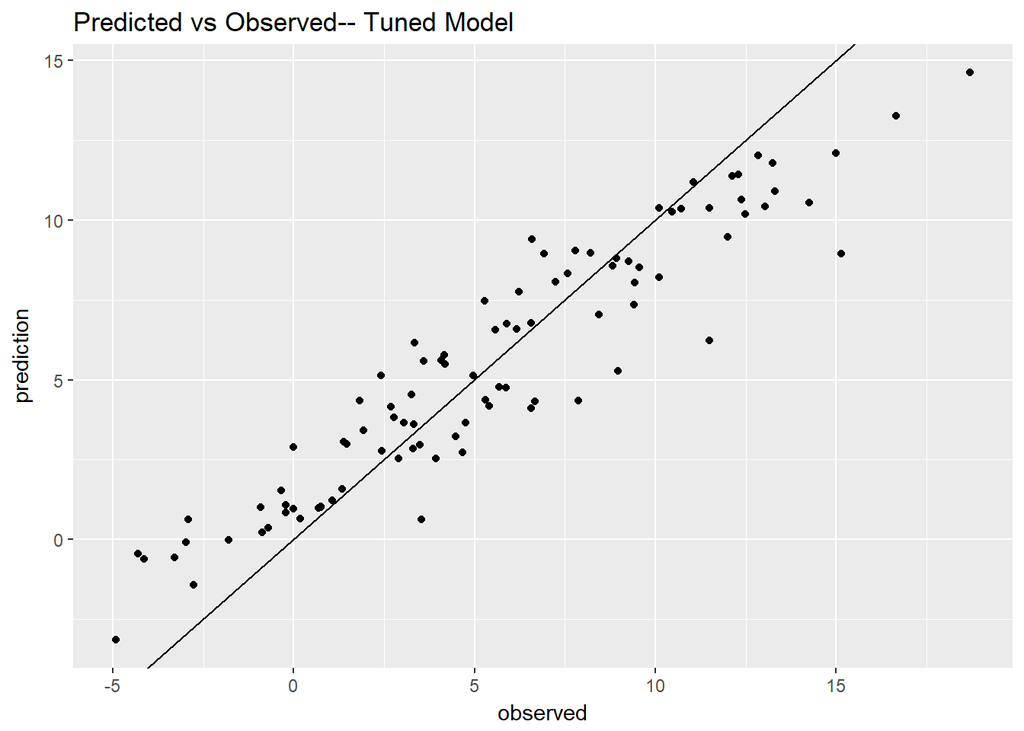

```r
ff1_pred <- predict(ff_fit, ind_vars)

ff2_pred <- predict(ff_fit2, ind_vars)
o_e <- data.frame(prediction = ff1_pred,
                  prediction2 = ff2_pred,
                  observed = resp_vars)

ggplot(data = o_e) + geom_point(mapping= aes(x = observed, y = prediction)) +
  labs(title = 'Predicted vs Observed-- Tuned Model') +
  geom_abline(slope = 1)
```

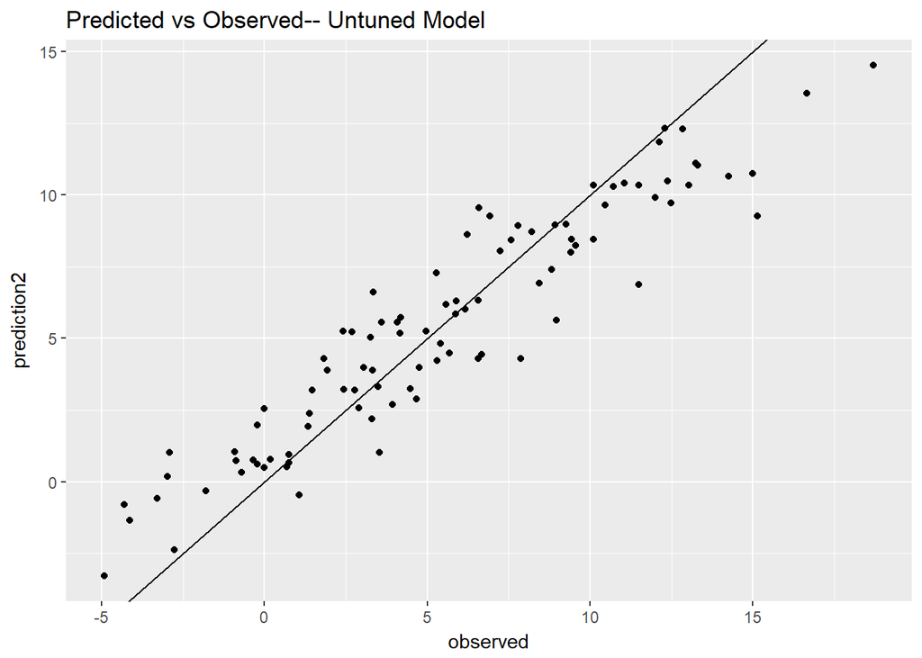

```r
ggplot(data = o_e) + geom_point(mapping = aes(x = observed, y = prediction2)) +
  labs(title = 'Predicted vs Observed-- Untuned Model') +
  geom_abline(slope = 1)
```

Finally, we consider comparing the observed and predicted observations. Note that since there was no test set, we simply make predictions on the data points we trained our model on. Hence, there will be some definite overfitting. We see that for the most part, that our data points are close to the y=x, suggesting a potential good fit. We see very similar fits for both tuned and untuned (the MSEs are too close together to notice any differences).

## Statistical Limitations

- No way to account for longitudinal design: This study had a longitudinal design which means that subjects had repeated measurements over time. In neither portion of this analysis, there was no means to account for correlations within subjects.
- No test set: There was no way to evaluate the validity of our model in part 2 since no test set was provided by the collaborator. Hence, we don’t actually know the true weaknesses of our model.
- Clinical significance: There was no way to assess clinical significance. While the results above show statistical significance, we need to ensure that the results make sense clinically. Extensive discussion with biology collaborators should take place to communicate findings.